# Introduction to Git and GitHub

Session - Pull Requests

Zoë Turner

## Pushing to the remote (GitHub)

We want to `push` the copy branch to GitHub, make a `pull request` to `merge` into main

```r
usethis::pr_push()
```

This open the pull request in GitHub/a browser, select the `Create Pull Request` button

**Draft pull requests**

- For public repositories it’s possible to change the pull request to a draft.
- In GitHub click on the down arrow on the green button for `Create pull request` and select Draft
- Click the green button again to make the pull request

## Extra unnecessary step?

- Creating a pull request to the `main` branch can be seen as an extra step, particularly when you are working alone
- But if you are working with others or the main is a *clean* working branch you need to protect it
- Pull requests will be where your *merge conflicts* will be highlighted
- People can see you are working on things
- You have a remote copy of your work if anything were to happen to your local computer!
- Reverting (undoing) a pull request is really easy in GitHub, even more so if you have a lot of commits

## Options to merge - default

There are three options the default being

`Create a merge commit` creates a new `merge commit` which isn’t very descriptive in the name

> Merge pull request #1 from Letxuga007/new_work

but is recommended as an easier way to debug for when things get muddled

## Squashing

`Squash and merge` details multiple commits in one

> New work (#1) * First commit for quarto document * Removed author

which is a nice way to keep all the commit messages but messages can get long

**Squashing**

- Atomic committing is a practice in Git versioning where each distinct step is committed
- Squashing is only used in this this practice if things are very closely related:  
  # updated titles  
  # renamed titles  
  # correct spelling in title

## Rebase

`Rebase and merge` keeps all the commits as you created them in a linear way

The history is more readable but can be tougher to resolve conflicts

[figure not shown]

Screenshot of the commits from a rebase merge

## Let’s pause!

Sometimes you need to go back to `main` to get changes from colleagues or create a new branch:

```r
usethis::pr_pause()
```

This does a few things

```markdown
✔ Setting active project to '/cloud/project'
✔ Switching back to the default branch.
✔ Checking that local branch 'new_work' has the changes in 'origin/new_work'
✔ Switching back to default branch ('main').
✔ Pulling changes from 'origin/main'
```

## Resuming your PR

First find the PR to work on:

```r
usethis::pr_fetch()
```

Gives you details of what is open as a PR:

```markdown
✔ Setting active project to '/cloud/project'
ℹ No PR specified ... looking up open PRs.
Which PR are you interested in? (0 to exit)

1: #1 (@Letxuga007): 'New work'
```

To resume then select the number or if you know the PR before then

```r
usethis::pr_fetch(1)
```

## Finish with the PR

- If the PR is set to Draft then, in GitHub, set to review
- If the PR was not a Draf the button `Merge pull request` will be available straight away
- Return to RStudio and type

```r
usethis::pr_finish()
```

Several things gets tidied up all in one function

```markdown
✔ Switching back to default branch ('main').
✔ Pulling changes from 'origin/main'
✔ Deleting local 'new_work' branch.
✔ PR 'Letxuga007/project/#1' has been merged, deleting remote branch 'origin/new_work'
```

## You might want to discard a PR

If you are working on something and change your mind

```r
usethis::pr_forget()
```

when in the branch you want to discard:

```markdown
✔ Switching back to default branch ('main').
✔ Pulling changes from 'origin/main'
✔ Deleting local 'mistake-branch' branch.
```

**PR needs to be tidied in GitHub**

- Because local is different to remote you will need to close any PR on GitHub

## Local and remote branches

Local and Remote branches are distinct things so although `new_work` branch has been deleted and the remote has been merged, the connection in RStudio remains

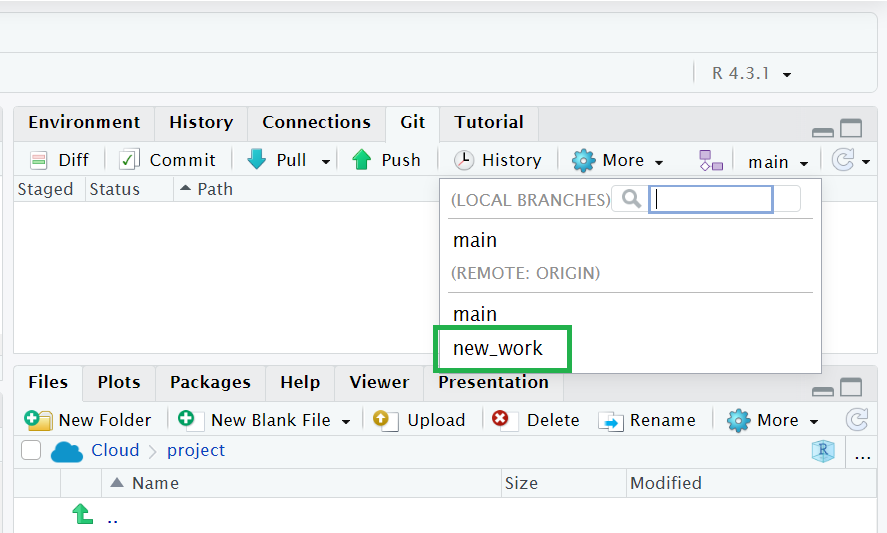

To tidy, in the Terminal type:

```bash
git remote prune origin
```

## End session

## Acknowledgements

[Happy Git and GitHub](https://happygitwithr.com/) for the useR by Jenny Bryan

[Pull Request Flow with usethis](https://www.garrickadenbuie.com/blog/pull-request-flow-usethis/?interactive=) by Garrick Aden-Buie